# The Pace of Life of Partial Migration

**[model this? could fit a gam with smooth by JD interacting tih strategy, RE of individual]**

**[@Nils, should we right truncate too? i.e., are there some observations that are too far into the breeding season to be useful? Also, can we better control for days since arrival than just raw Julian date?]**

```r
bodymass1 <- bodymass %>%
  ungroup() %>%
  left_join(tarsus) %>%
  mutate(period = case_when(julian.bird < 150 ~ "pre",
                   julian.bird >= 150 ~ "post")) %>%
  mutate(birdid.fk = factor(birdid.fk),
         bc = bodymass/tarsus) %>%
  filter(period == "post")
fm.bm <-gam(bc ~ s(julian.bird) + non.breeding.strategy*sex + s(birdid.fk, bs = "re"), data = bodymass1, method = "REML")
summary(fm.bm)
```

```
##
## Family: gaussian
## Link function: identity
##
## Formula:
## bc ~ s(julian.bird) + non.breeding.strategy * sex + s(birdid.fk,
##     bs = "re")
##
## Parametric coefficients:
##                                 Estimate Std. Error t value Pr(>|t|)
## (Intercept)                      2.66553    0.04500  59.236   <2e-16 ***
## non.breeding.strategyws          0.02509    0.05493   0.457    0.649
## sexMale                         -0.05342    0.07295  -0.732    0.467
## non.breeding.strategyws:sexMale -0.11485    0.08531  -1.346    0.183
## ---
## Signif. codes:  0 '***' 0.001 '**' 0.01 '*' 0.05 '.' 0.1 ' ' 1
##
## Approximate significance of smooth terms:
##                  edf Ref.df     F p-value
## s(julian.bird) 6.074  7.177 3.625 0.00238 **
## s(birdid.fk)   2.762 56.000 0.052 0.38253
## ---
## Signif. codes:  0 '***' 0.001 '**' 0.01 '*' 0.05 '.' 0.1 ' ' 1
##
## R-sq.(adj) =  0.363   Deviance explained = 46.6%
## -REML = -19.041  Scale est. = 0.02088   n = 74
```

```r
# calc cis using t distribution and SEs from the VCOV
Vb <- vcov(fm.bm, unconditional = TRUE)
se <- sqrt(diag(Vb))

# rdf <- df.residual(fm.bm)
# mult <- qt(0.975, df = rdf)
#
# cis <- se*mult
# fm.bm2 <-lmer(bodymass ~ period + non.breeding.strategy*sex + (1|birdid.fk), data = bodymass1)
# summary(fm.bm2)
```

We found no differences in body mass at the onset of the breeding season for migratory strategy (coefficient +/- SE: 0.0250851 $\pm$ 0.0601827), sex (coefficient +/- SE: -0.0534162 $\pm$ 0.0782538), or the interaction between the two (coefficient +/- SE: -0.1148465 $\pm$ 0.0928519) (Fig. 5).

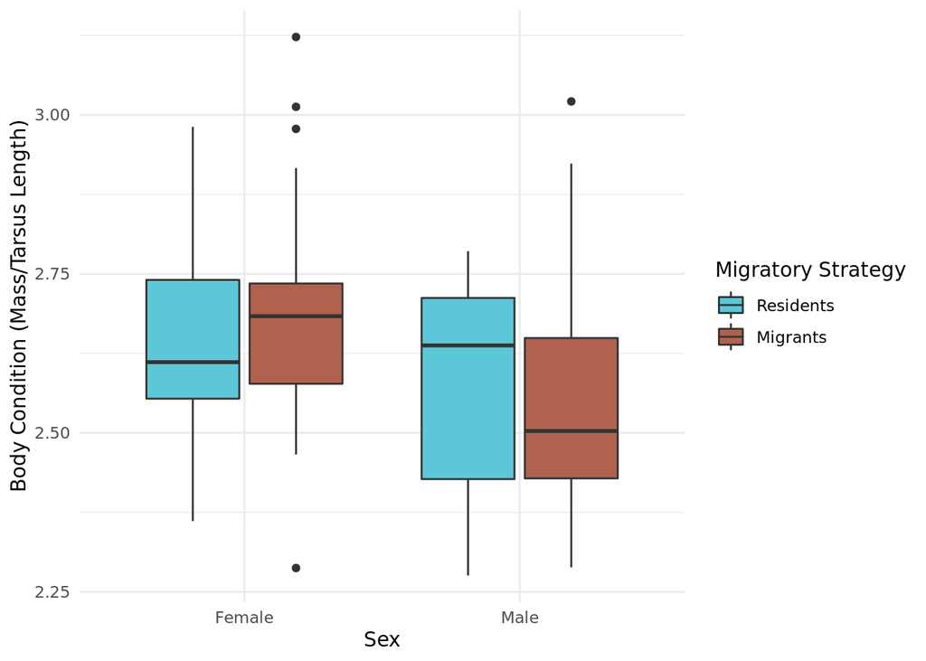

Fig. 5. Breeding season body condition (bodymass/tarsus length) by sex and migratory strategy

```r
ggplot(bodymass1) +
  geom_boxplot(aes(x=sex, y = bc, fill = non.breeding.strategy)) +
  scale_fill_manual(values = pal, labels = c("Residents", "Migrants"),
                     name = "Migratory Strategy") +
  ylab("Body Condition (Mass/Tarsus Length)") +
  xlab("Sex") +
  theme_minimal()
```

**DO WE WANT TO LEAVE THE ANLYSIS HERE OR STILL AIM FOR CONNECTING TO A DEB?**  
*Need to consider the ms complexity, timing of the availability of the DEB extension to `nichemapr`, target journal, as well as what exactly we could expect to get from the addition of a DEB etc.*  
*My $0.02: I think it would be nice to be able to point quantitatively to where we expect this to go - for which the DEB might be nice. That said, I suspect it might be very difficult to sensibly parameterize the DEB because the costs of migration itself are going to be very difficult to capture, especially those periods of tissue hypertrophy and atrophy that pre-/ante-cede migrations themselves and without those quantitatively account for, I’m not positive the DEB is going to be any more convincing than reasoning by logic alone… (see the bullet points in the discussion as of now)*